# The Trend of Vaccine-Preventable Diseases Over Time in the Americas and Europe

Julia Martin

2024-11-01

### This report has a [corresponding presentation](https://docs.google.com/presentation/d/1-mtQBr7bOPMI0FEOZE69pR2zCtD6Ybnn0AXOCWGZ4Bc/edit?usp=sharing) which better explains the process and hypothesis.

## Read in the necessary libraries

```r
library(tidyverse)
```

```r
library(ggplot2)
library(gridExtra)
```

## Step 1: Read in the csv files

```r
diptheria = read.csv("C:\\Users\\marin\\Downloads\\vaccine-preventable-communicable-diseases\\data\\Diptheria.csv.csv")
con_rubella = read.csv("C:\\Users\\marin\\Downloads\\vaccine-preventable-communicable-diseases\\data\\Congenital-Rubella-Syndrome.csv.csv")
measles = read.csv("C:\\Users\\marin\\Downloads\\vaccine-preventable-communicable-diseases\\data\\Measles.csv.csv")
mumps = read.csv("C:\\Users\\marin\\Downloads\\vaccine-preventable-communicable-diseases\\data\\Mumps.csv.csv")
neo_tenatus = read.csv("C:\\Users\\marin\\Downloads\\vaccine-preventable-communicable-diseases\\data\\Neonatal Tetanus.csv.csv")
polio = read.csv("C:\\Users\\marin\\Downloads\\vaccine-preventable-communicable-diseases\\data\\Poliomyelitis.csv.csv")
total_rubella = read.csv("C:\\Users\\marin\\Downloads\\vaccine-preventable-communicable-diseases\\data\\Total Rubella.csv")
total_tenatus = read.csv("C:\\Users\\marin\\Downloads\\vaccine-preventable-communicable-diseases\\data\\Total Tetanus.csv.csv")
yellow_fever = read.csv("C:\\Users\\marin\\Downloads\\vaccine-preventable-communicable-diseases\\data\\Yellow Fever.csv.csv")
```

## Step 2: Create functions to clean the datasets & remove unwanted information

```r
cleaner = function(dataset) {
  dataset = dataset %>%
    filter(SpatialDimension == "COUNTRY") %>%
    filter(TimeDimension == "YEAR") %>%
    filter(ParentLocation == "Americas" | ParentLocation == "Europe")

  #clean up the dataset
  dataset_c <- dataset[, !names(dataset) %in%
                             c("DisaggregatingDimension1", "DisaggregatingDimension2", "DisaggregatingDimension3",  "DisaggregatingDimension1ValueCode", "DisaggregatingDimension2ValueCode", "DisaggregatingDimension3ValueCode", "DataSourceDimension", "DataSourceDimensionValueCode", "Low", "High", "Comments", "SpatialDimension", "SpatialDimensionCode","ParentLocationCode", "SpatialDimensionValueCode", "TimeDimensionValue", "TimeDimensionBegin", "TimeDimensionEnd", "Date", "NumericValue", "Id", "TimeDimension")]

  dataset_c = dataset_c %>%
    arrange(desc(TimeDim))

  #rename the cols
  names(dataset_c) <- c("DiseaseCode", "Location", "Year", "PeopleSick")

  #turn the values in PeopleSick into ints
  dataset_c$PeopleSick <- suppressWarnings(as.numeric(as.character(dataset_c$PeopleSick)))

  #multiple year entries into one entry per year
  combined_data <- dataset_c %>%
    group_by(Location, Year, DiseaseCode) %>%
    summarise(combined = sum(as.numeric(PeopleSick), na.rm = TRUE), .groups = "drop")
}
```

## Step 3: Create a function to graph all individual datasets

```r
# Graphs which don't show the legend
grapher <- function(clean_dataset, title) {
  ggplot(clean_dataset, aes(x = Year, y = combined, color = Location, group = Location)) +
    geom_line(linewidth = 1) +
    ylim(NA, 71700) +
    labs(title = title, x = "Year", y = "# Cases") +
    theme_grey()
}
```

## Step 4: Clean all individual datasets

```r
clean_diptheria = cleaner(diptheria)
clean_con_rubella = cleaner(con_rubella)
clean_measles = cleaner(measles)
clean_mumps = cleaner(mumps)
clean_neo_tenatus = cleaner(neo_tenatus)
clean_polio = cleaner(polio)
clean_total_rubella = cleaner(total_rubella)
clean_total_tenatus = cleaner(total_tenatus)
clean_yellow_fever = cleaner(yellow_fever)
```

## Step 5: Make graphs for all individual datasets

```r
plot_diptheria <- grapher(clean_diptheria, "Diptheria")
plot_con_rubella <- grapher(clean_con_rubella, "Con.  Rubella Syndrome")
plot_measles <- grapher(clean_measles, "Measles")
plot_mumps <- grapher(clean_mumps, "Mumps")
plot_neo_tenatus <- grapher(clean_neo_tenatus, "Neonatal Tenatus")
plot_polio <- grapher(clean_polio, "Polio")
plot_total_rubella <- grapher(clean_total_rubella, "Total Rubella")
plot_total_tenatus <- grapher(clean_total_tenatus, "Total Tenatus")
plot_yellow_fever <- grapher(clean_yellow_fever, "Yellow Fever")
```

## Step 6: Graph datasets in a grid

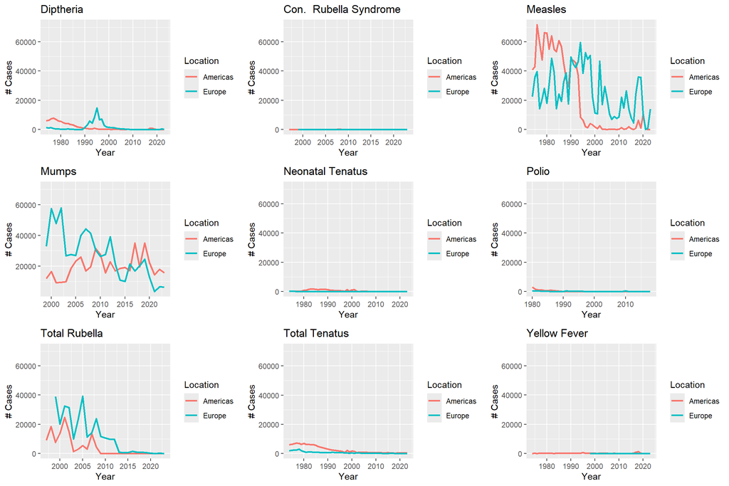

```r
# This is code created by chatGPT
grid.arrange(
  plot_diptheria, plot_con_rubella, plot_measles,
  plot_mumps, plot_neo_tenatus, plot_polio,
  plot_total_rubella, plot_total_tenatus, plot_yellow_fever,
  ncol = 3
)
```

Observing these, we can see that there are only 5 which have any substantial change. As they are now, we can’t find any correlations, so we’ll go ahead and put those 5 on the same graph.

## Step 7: Put all datasets onto one graph

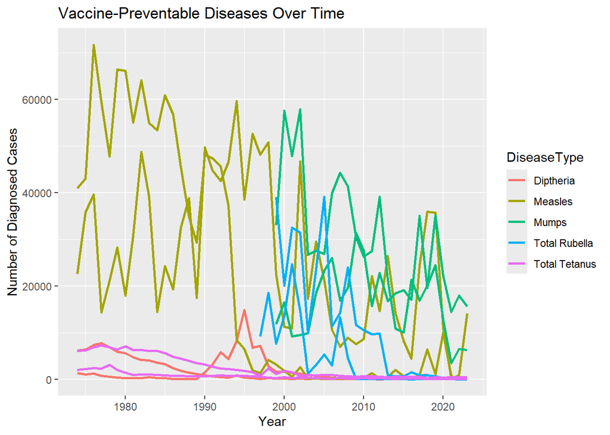

```r
# Add a DiseaseType column for each cleaned dataframe
clean_diptheria$DiseaseType <- "Diptheria"
clean_measles$DiseaseType <- "Measles"
clean_mumps$DiseaseType <- "Mumps"
clean_total_rubella$DiseaseType <- "Total Rubella"
clean_total_tenatus$DiseaseType <- "Total Tetanus"

# Combine all dataframes
all_diseases <- rbind(clean_diptheria, clean_measles, clean_mumps, clean_total_rubella, clean_total_tenatus)

# Graph everything together
  ggplot(all_diseases, aes(x = Year, y = combined, color = DiseaseType, group = interaction(Location, DiseaseType))) +
    geom_line(size = 1) +
    labs(title = "Vaccine-Preventable Diseases Over Time",
         x = "Year",
         y = "Number of Diagnosed Cases") +
    theme_grey()
```

A bit better, but the graph is too busy and we can’t differentiate between the two locations. To kill two birds with one stone, we should divide it into two: America and Europe.

## Step 8: Make a graph for each location

### Sorting function for each location

```r
#Make a sorting function for Americas
country_sorter = function(dataset, title, location) {
  new_dataset = dataset %>%
    filter(Location == location)
  new_dataset$DiseaseCode = title
  return(new_dataset)
}
```

### Graphing function for each location

```r
grapher_all <- function(dataset, title) {
  ggplot(dataset, aes(x = Year, y = combined, color = DiseaseType, group = interaction(Location, DiseaseType))) +
    geom_line(size = 1) +
    labs(title = title,
         x = "Year",
         y = "Number of Diagnosed Cases") +
    theme_grey()
}
```

### Make the Americas graph

```r
# Add a DiseaseType column for each cleaned dataframe
am_diptheria = country_sorter(clean_diptheria, "Diptheria", "Americas")
am_measles = country_sorter(clean_measles, "Measles", "Americas")
am_mumps = country_sorter(clean_mumps, "Mumps", "Americas")
am_total_rubella = country_sorter(clean_total_rubella, "Total Rubella", "Americas")
am_total_tenatus = country_sorter(clean_total_tenatus, "Total Tetanus", "Americas")

# Combine all dataframes
all_diseases_america <- rbind(am_diptheria, am_measles, am_mumps, am_total_rubella, am_total_tenatus)

# Plot all diseases (Americas) together
all_america = grapher_all(all_diseases_america, "Vaccine-Preventable Diseases Over Time in America")
```

### Make the Europe graph

```r
# Add a DiseaseType column for each cleaned dataframe
eu_diptheria = country_sorter(clean_diptheria, "Diptheria", "Europe")
eu_measles = country_sorter(clean_measles, "Measles", "Europe")
eu_mumps = country_sorter(clean_mumps, "Mumps", "Europe")
eu_total_rubella = country_sorter(clean_total_rubella, "Total Rubella", "Europe")
eu_total_tenatus = country_sorter(clean_total_tenatus, "Total Tetanus", "Europe")

# Combine all dataframes
all_diseases <- rbind(eu_diptheria, eu_measles, eu_mumps, eu_total_rubella, eu_total_tenatus)

# Plot all diseases (Europe) together
all_europe = grapher_all(all_diseases, "Vaccine-Preventable Diseases Over Time in Europe")
```

### Show the two graphs together

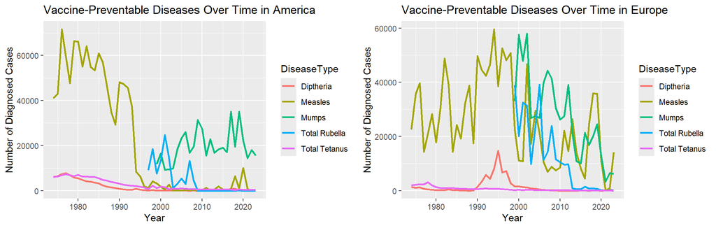

```r
grid.arrange(
  all_america, all_europe,
  ncol = 2
)
```

## Now we can really see the more subtle changes within each dataset.

### Americas:

I can see 3 timeframes where the diseases experience an some form of an uptick. In the 1980s, right before/during the year 2000, and possibly right before the 2020s. I can’t see any areas where the diseases experienced some form of downwards slope. The closest thing is when, from 1970 to 1995, where three (maybe four) diseases had a gradual negative slope.

### Europe:

Honestly, I can’t get much from this graph. There are only two or three diseases for each possible uptick shown, and the three main diseases that have any significant number of cases experience general volatility that makes it impossible to correlate with others. The one slight trend I can find is how, from 2005 to 2020, three diseases saw a gradual decrease in the height of the peaks experienced.

## How do those trends relate to global events?

I’m considering global events as possible explanations rather than events that just took place in the country as the world was (still is) so interconnected.

### Upticks:

- 1980s Fall of the Berlin Wall, AIDS epidemic, MTV was created
- 2000s Hurricane Katrina, War on Terrorism
- 2018/20 Humanitarian crises in Yemen & Venezuela, #MeToo Movement, Cilmate Change becomes a *very big thing*

### Downward Slopes:

1970/95 :

```
- 70s Vietnam War, Cold War, Beatles Breakup, Gay Liberation Movement,
- 80s Fall of the Berlin Wall, AIDS epidemic, MTV was created,
- 90s Dissolution of the Soviet Union, Operation Desert Storm, President Nelson Mandela elected, O.J. Simpson trial, Death of Princess Diana
```

2005/2020 :

```
- 05 Hurricane Katrina, War on Terrorism, London Underground Attacks, PIRA (Provisional Irish Republican Army) ends military campaign,
- 10s Haiti earthquake, Brexit, Trump election, same-sex marrage becmoes legal,
- 20s Trump aquitted of impeachment charges, George Floyd killing & subsequent protests, COVID-19 pandemic
```

### A Very Basic AI

#### The following is based on (very bad) code which I wrote and was jazzed up by chatGPT to make it actually work.

The goal of this AI is to check all years for a dataframe given and return whether one year was worringly high (mathematically an outlier). This allows people to identify when a disease might be more/less contagious for whatever reason in a given year. In a more advanced form it might be able to estimate the count for a disease in a future year.

### Create functions to find outliers display corresponding years

```r
# Function to find outliers and return both the values and years
find_outliers <- function(dataset) {
  dataset <- dataset %>%
    na.omit

  years = dataset$Year
  x = dataset$combined

  Q1 <- quantile(x, 0.25, na.rm = TRUE)
  Q3 <- quantile(x, 0.75, na.rm = TRUE)

  IQR <- Q3 - Q1

  lower_bound <- Q1 - 1.5 * IQR
  upper_bound <- Q3 + 1.5 * IQR

  # Identify indices of outliers
  outlier_indices <- which(x < lower_bound | x > upper_bound)

  # Extract outlier values and corresponding years using these indices
  outliers <- x[outlier_indices]
  outlier_years <- years[outlier_indices]

  # Return a data frame with years and outlier values
  return(data.frame(Year = outlier_years, OutlierValue = outliers))
}

# Function to display each outlier year and its value
display_outliers <- function(outliers) {
  for (i in 1:nrow(outliers)) {
    print(paste("Concerning value in year", outliers$Year[i],
                "with a value of", outliers$OutlierValue[i]))
  }
}
```

## Plug in data

### Diptheria

```r
diptheria_outliers = find_outliers(clean_diptheria)
display_outliers(diptheria_outliers)
```

```
## [1] "Concerning value in year 1974 with a value of 6138"
## [1] "Concerning value in year 1975 with a value of 6348"
## [1] "Concerning value in year 1976 with a value of 7315"
## [1] "Concerning value in year 1977 with a value of 7775"
## [1] "Concerning value in year 1978 with a value of 6857"
## [1] "Concerning value in year 1979 with a value of 5845"
## [1] "Concerning value in year 1980 with a value of 5571"
## [1] "Concerning value in year 1981 with a value of 4748"
## [1] "Concerning value in year 1982 with a value of 4087"
## [1] "Concerning value in year 1983 with a value of 4023"
## [1] "Concerning value in year 1984 with a value of 3546"
## [1] "Concerning value in year 1992 with a value of 5812"
## [1] "Concerning value in year 1993 with a value of 4372"
## [1] "Concerning value in year 1994 with a value of 8171"
## [1] "Concerning value in year 1995 with a value of 14802"
## [1] "Concerning value in year 1996 with a value of 6727"
## [1] "Concerning value in year 1997 with a value of 7179"
```

### Measles

```r
measles_outliers = find_outliers(clean_measles)
display_outliers(measles_outliers)
```

```
## [1] "Concerning value in year NA with a value of NA"
## [1] "Concerning value in year  with a value of "
```

### Mumps

```r
mumps_outliers = find_outliers(clean_mumps)
display_outliers(mumps_outliers)
```

```
## [1] "Concerning value in year 2000 with a value of 57602"
## [1] "Concerning value in year 2001 with a value of 47898"
## [1] "Concerning value in year 2002 with a value of 57881"
```

### Total Rubella

```r
tot_rub_outliers = find_outliers(clean_total_rubella)
display_outliers(tot_rub_outliers)
```

```
## [1] "Concerning value in year 1999 with a value of 38966"
## [1] "Concerning value in year 2001 with a value of 32505"
## [1] "Concerning value in year 2002 with a value of 31450"
## [1] "Concerning value in year 2005 with a value of 39126"
```

### Total Tenatus

```r
tot_ten_outliers = find_outliers(clean_total_tenatus)
display_outliers(tot_ten_outliers)
```

```
## [1] "Concerning value in year 1974 with a value of 6048"
## [1] "Concerning value in year 1975 with a value of 6214"
## [1] "Concerning value in year 1976 with a value of 6817"
## [1] "Concerning value in year 1977 with a value of 7252"
## [1] "Concerning value in year 1978 with a value of 6885"
## [1] "Concerning value in year 1979 with a value of 6362"
## [1] "Concerning value in year 1980 with a value of 7055"
## [1] "Concerning value in year 1981 with a value of 6247"
## [1] "Concerning value in year 1982 with a value of 6305"
## [1] "Concerning value in year 1983 with a value of 6063"
## [1] "Concerning value in year 1984 with a value of 6118"
## [1] "Concerning value in year 1985 with a value of 5572"
## [1] "Concerning value in year 1986 with a value of 4823"
```